# Validating a corpus

If we want to apply the MFA on own or external data using pretrained models and dictionaries, it is always good to check wether al the words in our transcription files are also included in the dictionary. If this is not the case, we have to modify the dictionary and add the missing words. This notebook shows how to use the validation function of the MFA.

The MFA provides a function that will check if sound files or transcriptions are missing and whether all words in our transcriptions have also an entry in a pronunciation dictionary. The command is:

```python
# mfa validate --clean PATH_TO_YOUR_DATA PATH_TO_YOUR_DICTIONARY
```

In order to test this function, we will use the Corpus_validation_dataset.zip and the french_mfa_dict_modified.txt from the Google Drive folder. THe zip archive contains wav and lab files from the first part of the SIWIS French Speech Synthesis corpus. Create a corpus folder and unpack the SIWIS data into it. Place the dictionary file somewhere you want. In this example I created a folder french_data in a Workspace/corpora/ directory, and the dictionary is in Workspace/corpora/. The full specified command is:

```python
! mfa validate --clean ~/Workspace/corpora/french_data/ ~/Workspace/corpora/french_mfa_dict_modified.txt
```

```
INFO - Setting up corpus information...
INFO - Loading corpus from source files...
INFO - Found 1 speaker across 120 files, average number of utterances per
                speaker: 120.0
INFO - Initializing multiprocessing jobs...
WARNING - Number of jobs was specified as 3, but due to only having 1 speakers,
                   MFA will only use 1 jobs. Use the --single_speaker flag if
                   you would like to split utterances across jobs regardless of
                   their speaker.
INFO - Normalizing text...
INFO - Creating corpus split for feature generation...
INFO - Generating MFCCs...
INFO - Calculating CMVN...
INFO - Generating final features...
INFO - Creating corpus split with features...

INFO - ******
INFO - Corpus
INFO - ******

INFO -   120 sound files
INFO -   120 text files
INFO -   1 speakers
INFO -   120 utterances
INFO -   393.680 seconds total duration

INFO -   Sound file read errors
INFO -   ======================

INFO -     There were no issues reading sound files.

INFO -   Feature generation
INFO -   ==================

INFO -     There were no utterances missing features.

INFO -   Files without transcriptions
INFO -   ============================

INFO -     There were no sound files missing transcriptions.
```

[output cut: 124 more lines]

```
INFO - Accumulating statistics...
INFO - monophone - Iteration 39 of 40
INFO - Accumulating statistics...
INFO - monophone - Iteration 40 of 40
INFO - Accumulating statistics...
INFO - Training complete!
INFO - Compiling training graphs...
INFO - Generating alignments...
INFO - Accumulating transition stats...
INFO - Finished accumulating transition stats!
INFO - Beginning phone LM training...
INFO - Collecting training data...
INFO - Training model...
INFO - Completed training in 115.4295105934143 seconds!
INFO - Done! Everything took 177.944 seconds
```

After you run this command, we will get a lot of information about our corpus at the beginning of the output under Corpus. This is general information about the corpus such as the number of utterances, total duration of all files, if sound files are borken and much more. Under Dictionary you will find information about out of vocabulary words, these are words in our transcriptioni that are missing in the dictionary. In case there are out of vocabulary words, you can open the utterance_oovs.txt, that was placed in the MFA directory and a newly created folder that has the same name as the folder of your corpus. This file provides information about the words that are missing and in which file we can find it.

When we open the utterance_oovs.txt, we will see the following entry:

neut_parl_s01_0110, french_data: 0.0-2.94: a, r, t, i, c, u, l, e, r, a, i

In this case, the word articulerai is missing and it occures in the utterance neut_parl_s01_s0110. If we open the dictionary and search for this word, we will see that it is not included.

We can anyway try to align the data:

```python
! mfa align --clean ~/Workspace/corpora/french_data/ ~/Workspace/corpora/french_mfa_dict_modified.txt french_mfa ~/Workspace/corpora/french_data_textgrids/
```

If we open the french_data_textgrids folder, we see that all of the 120 utterances were aligned, with the typical performance (based on the dictionary that does not include all possible pronunciation variations, of course). If we open the TextGrid with the missing word, we will see that there are no phone alignments for articulerai. Instead, we see spn which is a label for an unrecognized word.

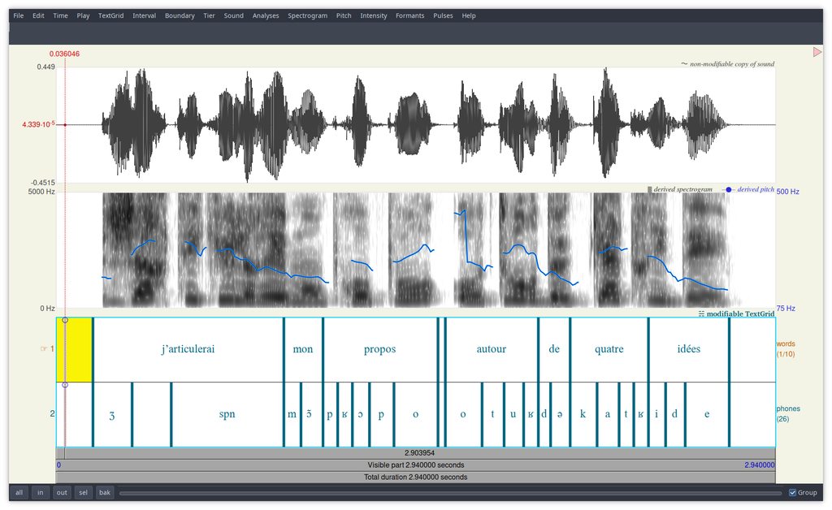

We can solve this problem by entering an entry for articulerai manually into the dictionary:

articuler a ʁ t i k y l e /*articulerai a ʁ t i k y l e ʁ e*/ articulo a ʁ t i k y l o articulé a ʁ t i k y l e articulée a ʁ t i k y l e articulées a ʁ t i k y l e

Be aware that you have to use the phone set of the respective dictionary for manual modifications. We run now the validation command again:

```python
! mfa validate --clean ~/Workspace/corpora/french_data/ ~/Workspace/corpora/french_mfa_dict_modified.txt
```

```python
! mfa align --clean ~/Workspace/corpora/french_data/ ~/Workspace/corpora/french_mfa_dict_modified.txt french_mfa ~/Workspace/corpora/french_data_textgrids/
```

If we open the new alignment of the file in question, we see that we have now the phone alignments for the once missing word.

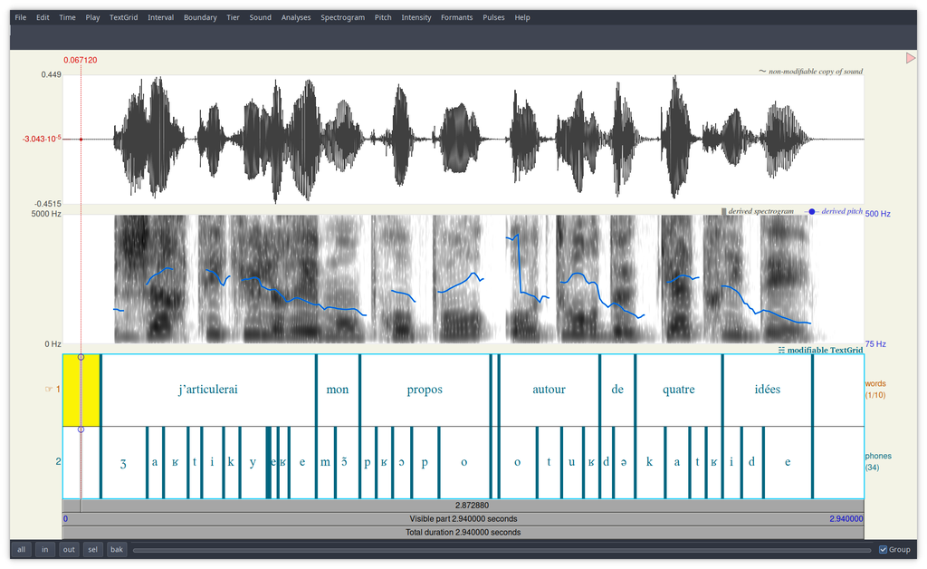

Before running the aligner on own or external data, it is best to run the validate command first, in order to find any errors in the corpus (missing files, entries in the dictionary). If it is necessary, the dictionary can always be extended manually. But in case you have multiple words missing, creating a dictionary using a g2p model may be preferred.